# Birthdays

### Users' Birthdays

This notebook follows the code from the previous video. Run the cells below to see the results. Also feel free to explore more on your own!

To start this notebook, we are going to look at a new idea in R called libraries. A library is essentially code that someone else wrote, packaged, and now you can use in your own projects.

One of the most popular libraries in R is ggplot2, which was created by Hadley Wickham to enable people to easily build beautiful data visualizations.

In this lesson, you will be gaining some practice with this library. To start using a library, you often need to install it as you saw in the previous video. However, on this machine, ggplot2 is already installed, so we can continue by simply telling R we would like to use the library by running the below command.

```r
library(ggplot2)
```

When using the `summary` or `mean` functions of the previous lessons, you were using functions that were in the `base` library.

Now that you have imported ggplot2 with the above command, an entire new set of functions is now available to you. You can see these new functions by clicking into the cell below and hitting tab.

```r
ggplot2::
```

An easy way to get started with ggplot2 is with the qplot function. Let's read in our data, and get started using the qplot function.

```r
fb = read.csv('./pseudo_facebook.tsv', sep='\t')
head(fb)
```

| userid | age | dob_day | dob_year | dob_month | gender | tenure | friend_count | friendships_initiated | likes | likes_received | mobile_likes | mobile_likes_received | www_likes | www_likes_received |
| --- | --- | --- | --- | --- | --- | --- | --- | --- | --- | --- | --- | --- | --- | --- |
| 2094382 | 14 | 19 | 1999 | 11 | male | 266 | 0 | 0 | 0 | 0 | 0 | 0 | 0 | 0 |
| 1192601 | 14 | 2 | 1999 | 11 | female | 6 | 0 | 0 | 0 | 0 | 0 | 0 | 0 | 0 |
| 2083884 | 14 | 16 | 1999 | 11 | male | 13 | 0 | 0 | 0 | 0 | 0 | 0 | 0 | 0 |
| 1203168 | 14 | 25 | 1999 | 12 | female | 93 | 0 | 0 | 0 | 0 | 0 | 0 | 0 | 0 |
| 1733186 | 14 | 4 | 1999 | 12 | male | 82 | 0 | 0 | 0 | 0 | 0 | 0 | 0 | 0 |
| 1524765 | 14 | 1 | 1999 | 12 | male | 15 | 0 | 0 | 0 | 0 | 0 | 0 | 0 | 0 |

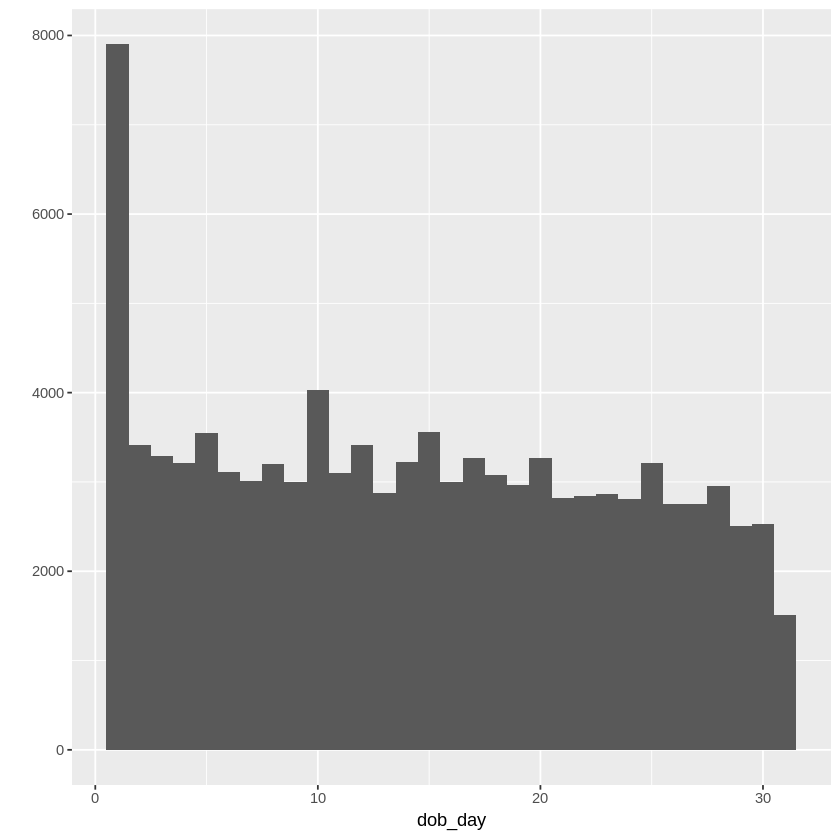

```r
qplot(x=dob_day, data=fb, bins=31)
```

We can also get other themes (though the default is pretty nice) by using another library called `ggthemes`. You do not have write access to the R library to add this library in the workspace. However, the below would work on your local machine.

```r
# install.packages('ggthemes', dependencies = TRUE)
# library(ggthemes)
```

Instead of using the qplot() function, you can also use the ggplot() function.

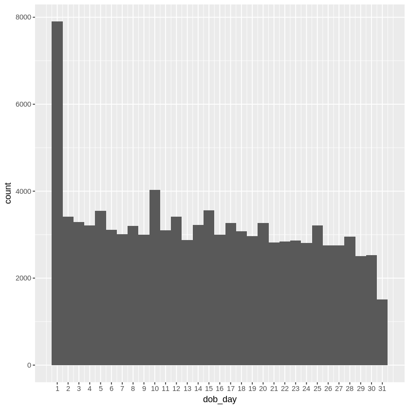

```r
ggplot(aes(x=dob_day), data=fb) +
        geom_histogram(binwidth=1) +
        scale_x_continuous(breaks=1:31)
```

This method of creating plots using ggplot has become much more popular than using qplot. The method is known as the grammar of graphics, which you can read more about in the white paper if you are interested: http://vita.had.co.nz/papers/layered-grammar.html.